# 2025 科展

## 題目: 不同隔音材料對聲音傳播之影響研究

#### 福豐國中 楊宇晴

```python
from IPython.display import display, HTML, Javascript

# 創建按鈕並設置隱藏或顯示代碼的功能
def toggle_code():
    display(HTML('''
        <script>
            code_show = false;
            function code_toggle() {
                if (code_show){
                    $('div.input').hide();
                    code_show = false;
                } else {
                    $('div.input').show();
                    code_show = true;
                }
            }
            $('#toggle_code_button').click(code_toggle);
        </script>
        <form action="javascript:code_toggle()">
            <input type="button" value="顯示/隱藏代碼" id="toggle_code_button">
        </form>
    '''))

toggle_code()
```

```python
import pandas as pd
import numpy as np
from scipy.stats import f_oneway, f
import matplotlib.pyplot as plt
%matplotlib inline

df0 = pd.read_excel('data.xlsx', sheet_name='非牛頓')
#print(df)
```

# 實驗結果與分析

## 實驗流程說明

我們的分析方法如下圖:

1. 首先探討與制定控制變因
2. 採用ANOVA分析, 針對實驗組與對照組進行分析. 我們採用P-value為0.05為標準, 小於此標準為顯著.
3. 如果ANOVA分析結果不顯著, 則重新探討與制定控制變因 (回到第1點).
4. 若ANOVA分析結果顯著, 我們再判斷控制變因是否為連續型資料. 若為連續型資料, 則採用迴歸分析繼續分析控制變因, 反之則採用箱型圖分析.

[figure not shown]

## ANOVA分析介紹

ANOVA分析的精神就是**最大化組間變異**與**最小化組內變異**. **最大化組間變異**目的是希望實驗的控制變因是有顯著的, **最小化組內變異**的目的是希望實驗水準夠高, 量測誤差很小. 因此ANOVA分析制定: $F=\frac{MS_B}{MS_W}$, 其中${MS_B}$為組間均方和, 我們期望越大越好, 代表控制變因顯著. ${MS_W}$為組內均方和, 越小越好, 代表量測誤差小. 最後透過F查表P-Value, 我們設定0.05為顯著水準.

[figure not shown]

### 實驗1: 非牛頓流體的隔音效果

#### 控制變因: 非牛頓流體的薄與厚

#### 實驗組: **薄的非牛頓流體**與**厚的非牛頓流體**

#### 對照組: 原音量(無隔音促施)

#### 1.1 ANOVA分析結果: 顯著 (P-value = 6.256896e-17 < 0.05 顯著水準)

```python
df = df0[['原音量', '非牛頓_薄', '非牛頓_厚']]

# 計算 ANOVA 表格的各個組成部分
# 群組數量：DataFrame 的欄數
n_groups = len(df.columns)
# 總觀測數量：每個群組的樣本數乘以群組數量
n_total = len(df) * n_groups

# 計算總平均值 (grand_mean) 和每個群組的平均值
grand_mean = np.mean(df.values)  # 所有觀測值的平均值
group_means = df.mean()  # 各群組的平均值

# 計算平方和 (Sum of Squares, SS)
# 組間平方和 (SSB)：反映各群組平均值與總平均值之間的差異
SSB = sum(len(df) * (mean - grand_mean) ** 2 for mean in group_means)

# 組內平方和 (SSW)：反映群組內部數據的變異程度
SSW = sum(sum((df[col] - group_means[col]) ** 2) for col in df.columns)

# 總平方和 (SST)：組間平方和與組內平方和之和
SST = SSB + SSW

# 計算自由度
# 組間自由度：群組數量減 1
df_between = n_groups - 1
# 組內自由度：總觀測數量減去群組數量
df_within = n_total - n_groups
# 總自由度：總觀測數量減去 1
df_total = n_total - 1

# 計算平方均值 (Mean Squares, MS)
# 組間平方均值：組間平方和除以組間自由度
MSB = SSB / df_between
# 組內平方均值：組內平方和除以組內自由度
MSW = SSW / df_within

# 計算 F 統計量
# F 值 = 組間平方均值 / 組內平方均值
F = MSB / MSW

# 計算對應的 p 值
# 使用 scipy.stats.f.sf 計算 F 分布的右尾概率，即 p 值
p_value = f.sf(F, df_between, df_within)

#可以直接套用f_oneway函數計算每個群組之間的F統計量與對應的p值,用來檢視F與p_value是否算錯
#f_stat, p_value_anova = f_oneway(df["Group1"], df["Group2"], df["Group3"], df["Group4"])

# 建立 ANOVA 表格，整合計算結果方便查看
anova_table = pd.DataFrame({
    "Source": ["Between Groups", "Within Groups", "Total"],
    "SS": [SSB, SSW, SST],
    "df": [df_between, df_within, df_total],
    "MS": [MSB, MSW, None],
    "F": [F, None, None],
    "p-value": [p_value, None, None]
})

# 顯示 ANOVA 表格
print(anova_table)
```

```
           Source           SS  df           MS         F       p-value
0  Between Groups  3464.666667   2  1732.333333  62.51789  6.256896e-17
1   Within Groups  2161.333333  78    27.709402       NaN           NaN
2           Total  5626.000000  80          NaN       NaN           NaN
```

#### 1.2 箱型圖分析

加了薄的非牛頓流體與厚的非牛頓流體的隔音效果, 遠比沒有任何隔音效果顯著較低. 但是薄的非牛頓流體與厚的非牛頓流體沒有顯著差異. 因此我們懷疑是填充非牛頓流體的空隙面積影響. 我們在下一個實驗將空隙面積做為控制邊因, 持續研究隔音的效果.

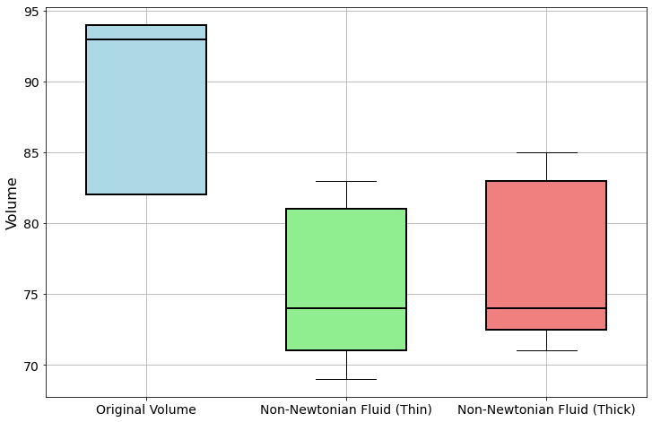

```python
# Plot a boxplot
plt.figure(figsize=(12, 8))

# Create a boxplot with custom widths, colors, and larger text
boxplot = plt.boxplot(
    [df["原音量"], df["非牛頓_薄"], df["非牛頓_厚"]],
    patch_artist=True,  # Allows filling the box with color
    widths=0.6,  # Increase the box width
    boxprops=dict(linewidth=2),
    medianprops=dict(linewidth=2, color="black"),
    labels=["Original Volume", "Non-Newtonian Fluid (Thin)", "Non-Newtonian Fluid (Thick)"]
)

# Apply colors to the boxes
colors = ['lightblue', 'lightgreen', 'lightcoral']
for patch, color in zip(boxplot['boxes'], colors):
    patch.set_facecolor(color)

# Set title and labels with larger font size
# plt.title("Comparison of Original Volume, With Box (No Foam), and With Box (Foam)", fontsize=16)
plt.ylabel("Volume", fontsize=16)
plt.xticks(fontsize=14)
plt.yticks(fontsize=14)
plt.grid(True)
plt.show()
```